# act_report

## Introduction:

#### The below analysis provides few insights into tweets from #WeRateDogs twitter account. Most of my analysis revolves around the time of tweet generation. For the pupose of this analysis my looking into a dataset of tweets generated between Nov-2015 to Aug-2017 This analysis consists of source of the tweets, the time (hour) of the day of the tweet generated and the trend of the retweets and the favorite tweets over the time.

## Findings:

### Smartphones (iPhone) are man's best friends too...

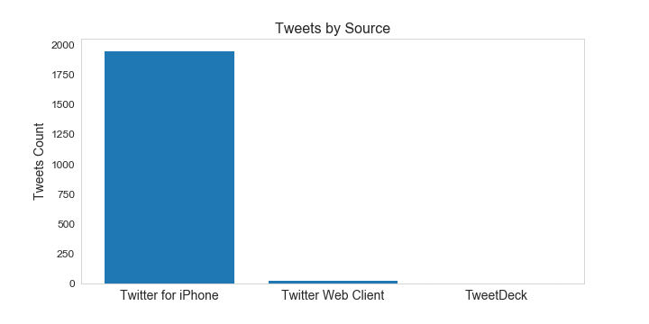

**In this smartphone era, it comes as no suprise that out of all the tweets tweeted on this account, more than 98% are tweeted using iPhones. The twitter web client is other popular source for these tweets.**

### This twitter account usually lights up after midnight...

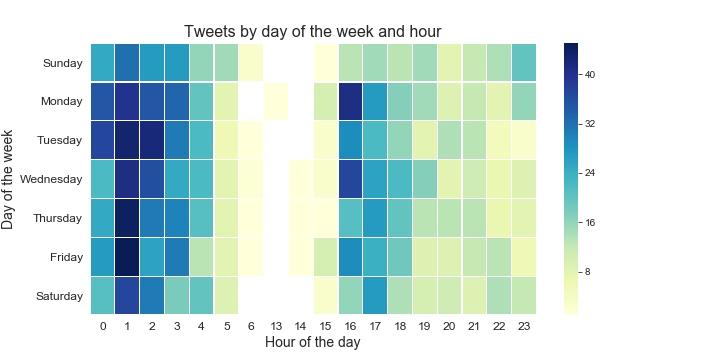

**This is interesting to know that all the tweets on the accounts are generated between noon and early morning. The tweets seems to disappear during the morning hours. This might be due to the fact that most of the people are away from home and their pet friends during the morning hours. But, it is also very interesting to know that highest number of tweets are generated after midnight. The account seems more active after midnight during the start of the week.**

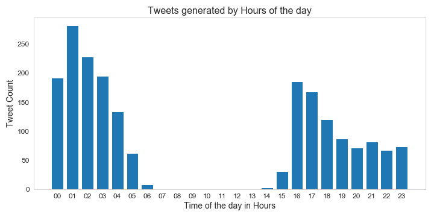

**From the above figure we can clearly see that most of the tweets are generated during the early hours between 12 am to 4 am and in the evening between 4 to 6 pm**

### We are famous, Brent...

[figure not shown]

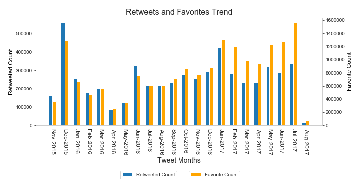